# Practical Machine Learning - Course Project

Peter Cebo

23/11/2019

## Introduction

In this project, we use data from accelerometers on the belt, forearm, arm, and dumbell of 6 participants. The goal is to predict the manner in which participants exercised. This is the “classe” variable in the training set, with 5 outcomes (A,B,C,D,E).

Data source: http:/groupware.les.inf.puc-rio.br/har.

This report will describe: a) how the prediction models were built b) how cross validation was used c) what the expected out of sample error is, and d) why the choices that were made, were made.

Finally, the created model will be used to predict 20 test cases.

## Cleaning and Prepping Data

```r
training <- read.csv("https://d396qusza40orc.cloudfront.net/predmachlearn/pml-training.csv")
testing <- read.csv("https://d396qusza40orc.cloudfront.net/predmachlearn/pml-testing.csv")

dim(training)
```

```
## [1] 19622   160
```

```r
#head(training) (omitted here for brevity)

length(which(sapply(training, anyNA)))
```

```
## [1] 67
```

```r
training[training==""] <- NA
useVar <- data.frame(seq_along(ncol(training)))
denom <- nrow(training)

for (i in 1:ncol(training)){
  if(sum(is.na(training[,i]))/denom>0.9){
    useVar[i]=FALSE
    }
  else{
    useVar[i]=TRUE
    }
}

training <- training[,useVar==TRUE]
training <- training[,-(1:7)]
dim(training)
```

```
## [1] 19622    53
```

```r
anyNA(training)
```

```
## [1] FALSE
```

A large portion of the variables (columns) have a large proportion of blank values and/or NAs. Since we confirm this proportion to be very high (>90%), we decide to simply exclude those variables from the training set. We also drop the first 7 columns, since they are data about user names / timestamps etc. and will not be useful to us (and doing so will allow us to calculate things like correlation easily).

The result is 53 variables and a “tidy” dataset, with no “NA” values.

***Side Note: A look at the raw data in tabular form shows why many of the variables are missing data - they are present when “new_window” = “yes”. This may be some sort of calibration data for each new measurement series and it might be useful to fill in the missing values with the values from the row of the same “num_window.” For simplicity (and because we can’t find documentation to confirm this), we choose to simply delete the variables.

Next, we create a validation dataset using a 60/40 split.

```r
suppressMessages(library(caret))
inTrain = createDataPartition(training$classe, p = 0.6)[[1]]
train <- training[inTrain,]
validate <- training[-inTrain,]
```

## Exploratory Data Analysis

Next, we do some quick exploratory data analysis, which will help us decide how to build our models (e.g. whether to use preProcess or not.)

```r
#Using the same methodology as in a week 2 lecture example:
M <- abs(cor(train[,-53]))
diag(M) <- 0
paste("There are", dim(which(M > 0.8, arr.ind=T))[1]/2, "variables that have a correlation of at least 0.8.")
```

```
## [1] "There are 19 variables that have a correlation of at least 0.8."
```

```r
which(M > 0.95, arr.ind=T)
```

```
##                  row col
## total_accel_belt   4   1
## accel_belt_z      10   1
## accel_belt_x       8   2
## roll_belt          1   4
## accel_belt_z      10   4
## pitch_belt         2   8
## roll_belt          1  10
## total_accel_belt   4  10
## gyros_dumbbell_z  33  31
## gyros_dumbbell_x  31  33
## gyros_forearm_z   46  33
## gyros_dumbbell_z  33  46
```

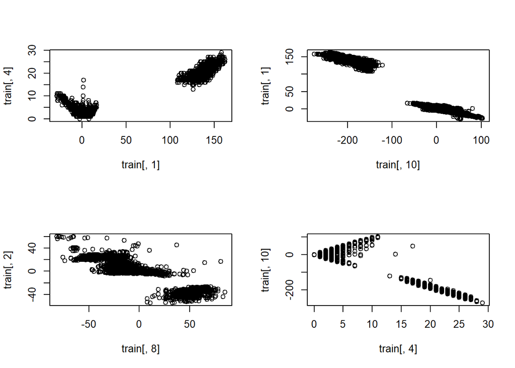

```r
par(mfrow=c(2,2))
plot(train[,1],train[,4])
plot(train[,10],train[,1])
plot(train[,8],train[,2])
plot(train[,4],train[,10])
```

## Building Model(s)

Next, we train some models on our training (train) set. We use multiple methods, with the intention of comparing and potentially combining them later in our analysis. Since we found significant correlation among variables, we ensure use principal component analysis in building our models - this should help with speed of model building.

```r
#First, enable parallel training (my PC has 8 cores)
suppressMessages(library(doParallel))
cl <- makePSOCKcluster(8)
registerDoParallel(cl)

rfModel <- train(classe ~ ., method="rf", preProcess="pca", data=train)
bModel <- train(classe ~ ., method="gbm", preProcess="pca", data=train, verbose=FALSE)
lModel <- train(classe ~ ., method="lda", preProcess="pca", data=train)
tbModel <- train(classe ~ ., method="treebag", preProcess="pca", data=train)
abModel <- train(classe ~ ., method="AdaBag", preProcess="pca", data=train)
kModel <- train(classe ~ ., method="knn", preProcess="pca", data=train)

rfPreds <- predict(rfModel, validate)
bPreds <- predict(bModel, validate)
lPreds <- predict(lModel, validate)
tbPreds <- predict(tbModel, validate)
abPreds <- predict(abModel, validate)
kPreds <- predict(kModel, validate)

#commented out for brevity
#confusionMatrix(rfPreds, validate$classe)$overall[1]
#confusionMatrix(bPreds, validate$classe)$overall[1]
#confusionMatrix(lPreds, validate$classe)$overall[1]
#confusionMatrix(tbPreds, validate$classe)$overall[1]
#confusionMatrix(abPreds, validate$classe)$overall[1]
#confusionMatrix(kPreds, validate$classe)$overall[1]

predDF1 <- data.frame(rfPreds, bPreds, tbPreds, kPreds, classe=validate$classe)
combModel1a <- train(classe ~ ., method="rf", data=predDF1)
combPreds1a <- predict(combModel1a, validate)
combModel1b <- suppressMessages(train(classe ~ ., method="gam", data=predDF1))
combPreds1b <- predict(combModel1b, validate)
predDF2 <- data.frame(rfPreds, bPreds, lPreds, tbPreds, abPreds, kPreds, classe=validate$classe)
combModel2a <- train(classe ~ ., method="rf", data=predDF2)
combPreds2a <- predict(combModel2a, validate)
combModel2b <- train(classe ~ ., method="gam", data=predDF2)
combPreds2b <- predict(combModel2b, validate)
confusionMatrix(combPreds1a, validate$classe)$overall[1]
```

```
##  Accuracy
## 0.9760387
```

```r
confusionMatrix(combPreds1b, validate$classe)$overall[1]
```

```
##  Accuracy
## 0.4719602
```

```r
confusionMatrix(combPreds2a, validate$classe)$overall[1]
```

```
##  Accuracy
## 0.9765486
```

```r
confusionMatrix(combPreds2b, validate$classe)$overall[1]
```

```
##  Accuracy
## 0.4723426
```

After creating 6 models and combining them in 4 different ways, we choose combined model 1a. Though model 2a was very slightly more accurate during cross-validation, it is more computationally expensive and we (arbitrarily, admittedly) choose 1a as our winner.

```r
rfPredsTest <- predict(rfModel, testing)
bPredsTest <- predict(bModel, testing)
tbPredsTest <- predict(tbModel, testing)
kPredsTest <- predict(kModel, testing)

#Not used - calculated for interest
#lPredsTest <- predict(lModel, testing)
#abPredsTest <- predict(abModel, testing)

predDFTest <- data.frame(rfPreds=rfPredsTest, bPreds=bPredsTest, tbPreds=tbPredsTest, kPreds=kPredsTest)

combPredTest <- predict(combModel1a, predDFTest)
combPredTest
```

```
##  [1] B A A A A E D B A A B C B A E E A B B B
## Levels: A B C D E
```

Finally, we find our predicted values on the testing set above.

## Appendix

We build two final models. One on the full training set (no cross-validation), and one on the 60% train set, but with no PCA to compare its results. Naturally, both these models take much longer to train and so had the dataset been larger, they may not have been an option!

```r
fullTrainModel <- train(classe ~., method="rf", data=training)

fullTrainModelPreds <- predict(fullTrainModel, testing)
fullTrainModelPreds
```

```
##  [1] B A B A A E D B A A B C B A E E A B B B
## Levels: A B C D E
```

```r
rfModelnoPCA <- train(classe ~ ., method="rf", data=train)
rfModelnoPCAPreds <- predict(rfModelnoPCA, testing)
rfModelnoPCAPreds
```

```
##  [1] B A B A A E D B A A B C B A E E A B B B
## Levels: A B C D E
```

Thanks for reading!